# TITANIC notebook

## EDA Krok 3

### Analiza pojedynczych zmiennych

#### Analizuję każdy atrybut indywidualnie, patrząc na jego rozkład, unikalne wartości i typ danych

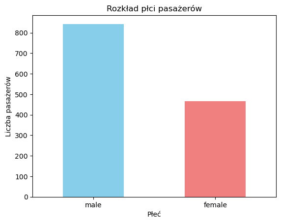

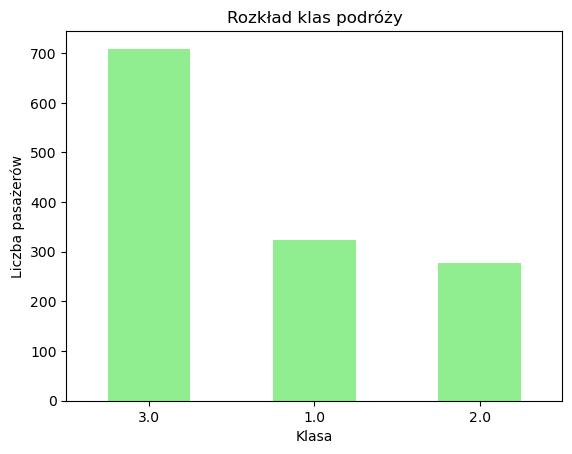

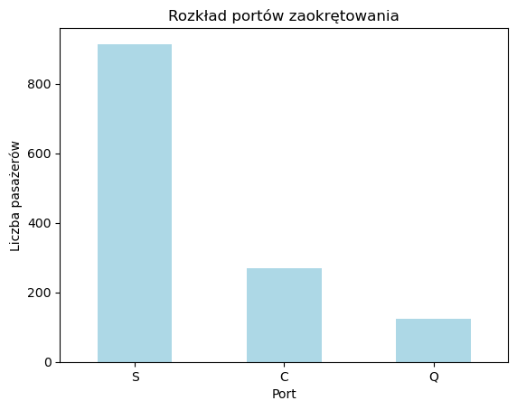

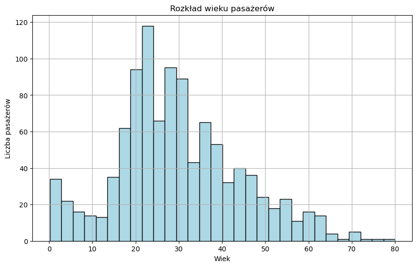

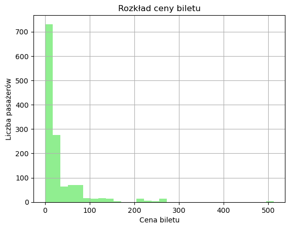

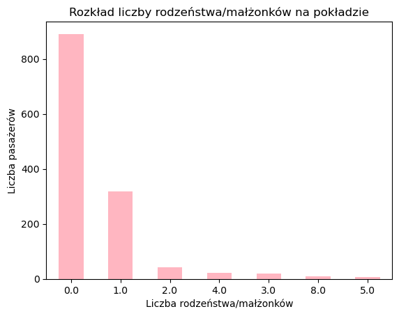

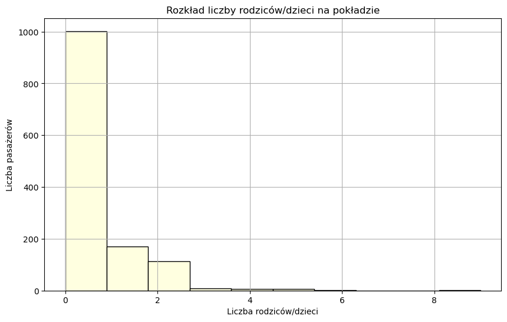

### Dodatkowo możemy pokazac jeszcze typ danych i unikalne wartości w tym kroku

```
pclass          3
survived        2
name         1307
sex             2
age            98
sibsp           7
parch           8
ticket        929
fare          281
cabin         186
embarked        3
boat           27
body          121
home.dest     369
dtype: int64
```

```
pclass       float64
survived     float64
name          object
sex           object
age          float64
sibsp        float64
parch        float64
ticket        object
fare         float64
cabin         object
embarked      object
boat          object
body         float64
home.dest     object
dtype: object
```

### WNIOSKI z analizy pojedynczych danych:

1. Płynęło więcej mężczyzn niż kobiet.
2. Najwięcej pasażerów płynęło z klasy 3 - ponad 700 osób, potem klasy 1 - ponad 300osób i najmniej z klasy 2 prawie 300 osób.
3. Największa liczba pasażerów wsiadała na statek z portu Southampton (S), potem z portu Cherbourg (C), a najmniej pasażerów wsiadło w porcie Queenstown (Q).
4. Najwieksza liczba pasażerów była w wieku 20 - 30 lat, a najmniejsza w wieku 60 - 80 lat.
5. Najwięcej pasażerów miało bilety najtańsze czyli zgadza się z wnioskami, ze pasażerów z klasy 3 było najwięcej.
6. Największa liczba pasażerów płynęła sama co pokazuje wykres liczby dzieci/rodziców oraz rodzeństwa/małżonków.
7. 8 z płynących rodzin było najliczniejszych.